# Primer of Ecology with $\textsf{R}$: chapter 4 Problems (Lumpies)

### Molly’s attempts:

1. Use the Lande model to compare 9 levels of destruction (`ds <- seq(0,.8, by=.1)`), using $c_i = 0.1, e = 0.01$. Graph the dynamics through time.

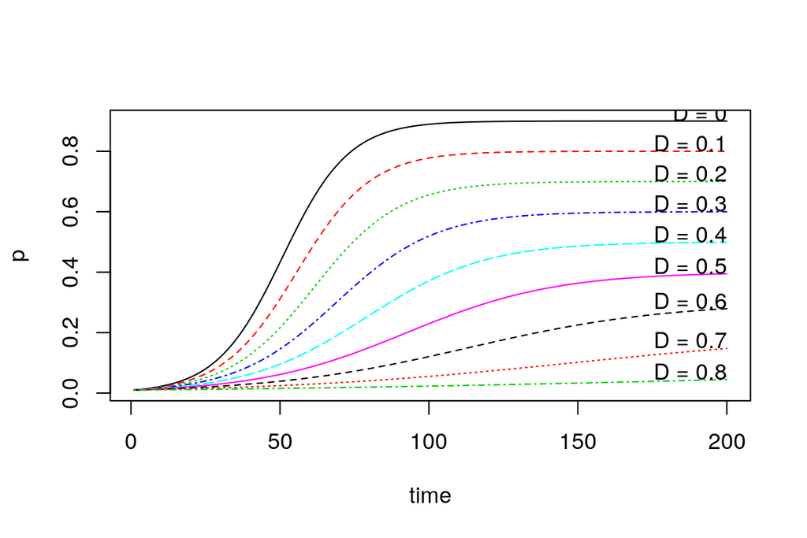

```r
### copied pretty much exactly from the text...
library(deSolve)
prmsD <- c(ci = 0.1, e = 0.01, D = 0)
Ds <- seq(0,.8, by=.1)
Initial.p <- 0.01
t <- 1:200

lande <- function(t, y, parms) {
  p <- y[1]
  with(as.list(parms), {
    dp <- ci * p * (1 - D - p) - e * p
    return(list(dp))
  })
}

ps <- sapply(Ds, function(d) {
  prmsD["D"] <- d
  ode(y = Initial.p, times = t, func = lande, parms = prmsD)[, 2]
})

matplot(t, ps, type = "l", ylab = "p", xlab = "time")
text(c(200, 200, 200), ps[200, ], paste("D = ", Ds, sep = ""),
     adj = c(1, 0))
```

2. Write an ODE function for a habitat destruction model with rescue effect. Let the “rescue” have an additional parameter, $a$, such that extinction rate is $ep(1 − ap)$.

```r
lande_rescue <- function(t, y, parms) {
  p <- y[1]
  with(as.list(parms), {
    dp <- ci * p * (1 - D - p) - e * p * (1 - a * p)
    return(list(dp))
  })
}
```

3. Let $D = 0.5, c_i = 0.1, e = 0.02$, and vary $a$ over five levels (including $a = 0, 1$) to investigate the effects of “relative rescue effect” on the equilibria and dynamics of a metapopulation.

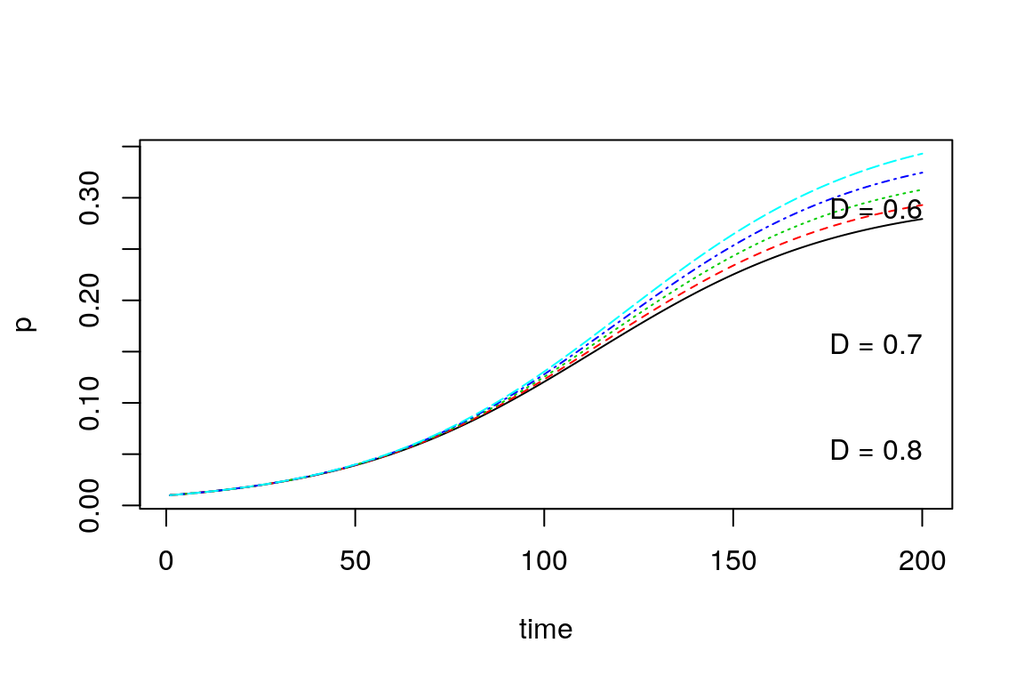

```r
prmsA <- c(ci = 0.1, e = 0.02, D = 0.5, a = 0)
as <- seq(0, 1, by = .25)
Initial.p <- 0.01
t <- 1:200

ps2 <- sapply(as, function(a) {
  prmsA["a"] <- a
  ode(y = Initial.p, times = t, func = lande_rescue, parms = prmsA)[, 2]
})

matplot(t, ps2, type = "l", ylab = "p", xlab = "time")
text(c(200, 200, 200), ps[200, ], paste("D = ", Ds, sep = ""),
     adj = c(1, 0))
```

### Casey:

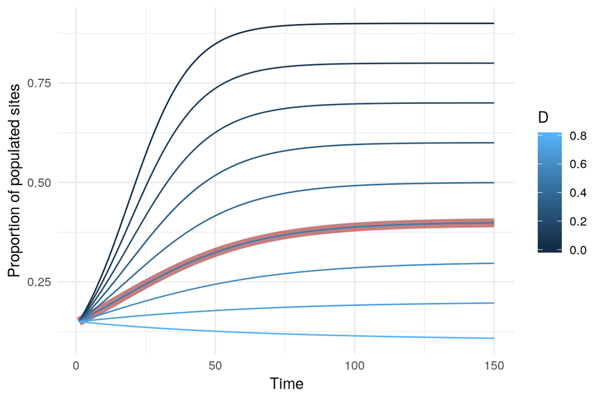

```r
### Write Lande function to accept various values of D for ODE solver
lande_cco <- function(t, y, parms) {
  p <- y[1]
  with(as.list(parms), {
    dp_dt <- c_i * p * (1 - D - p) - e * p
    return(list(dp_dt))
  })
}

### set up vector of Ds and initial vals
D_vec <- seq(0, .8, .1)
t_vec <- 1:150
p_0   <- .15

params <- c(c_i = 0.1, e = 0.01, D = 0)

### Run ODE on the whole shebang
p_list <- lapply(D_vec, function(D) {
  # D <- D_vec[2]
  params$D <- D
  p_vec <- ode(y = p_0, times = t_vec, func = lande_cco, parms = params) %>%
    as.data.frame() %>%
    setNames(c('t', 'p')) %>%
    mutate(D = D)
})

p_df <- bind_rows(p_list)

ggplot(p_df, aes(x = t, y = p, color = D)) +
  geom_line(data = p_df %>% filter(D == .5),
            color = 'red4', alpha = .5, size = 3) +
  geom_line(aes(group = D)) +
  theme_minimal() +
  labs(x = 'Time',
       y = 'Proportion of populated sites')
```

```r
### Write Lande function to accept various values of D for ODE solver
lande_a_cco <- function(t, y, parms) {
  p <- y[1]
  with(as.list(parms), {
    dp_dt <- c_i * p * (1 - D - p) - e * p * (1 - a * p)
    return(list(dp_dt))
  })
}
```

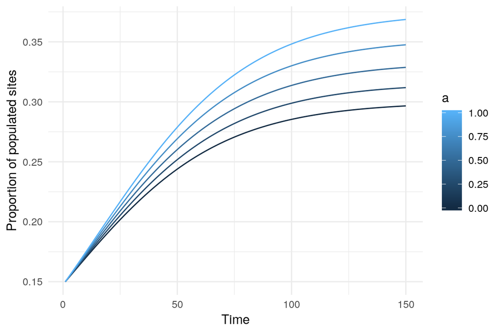

```r
### set up vector of a values and initial param vals
a_vec <- seq(0, 1, .25)
t_vec <- 1:150
p_0   <- .15

params <- c(c_i = 0.1, e = 0.02, D = 0.5, a = 0)

### Run ODE on the whole shebang
p_list2 <- lapply(a_vec, function(a) {
  # a <- a_vec[2]
  params$a <- a
  p_vec <- ode(y = p_0, times = t_vec, func = lande_a_cco, parms = params) %>%
    as.data.frame() %>%
    setNames(c('t', 'p')) %>%
    mutate(a = a)
})

p_df2 <- bind_rows(p_list2)

ggplot(p_df2, aes(x = t, y = p, color = a)) +
  geom_line(aes(group = a)) +
  theme_minimal() +
  labs(x = 'Time',
       y = 'Proportion of populated sites')
```

At $a = 0$, rescue effect is non-existent, so should look like standard Lande with $D = 0.5$ (from part a) when all parameters are the same, and higher when $a > 0$. Rerun with $c_i = 0.1, e = 0.01$ as in the first sim.

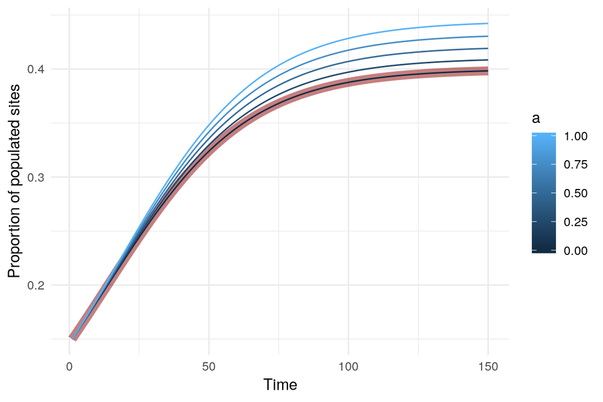

```r
### set up vector of a values and initial param vals
a_vec <- seq(0, 1, .25)
t_vec <- 1:150
p_0   <- .15

params <- c(c_i = 0.1, e = 0.01, D = 0.5, a = 0)

### Run ODE on the whole shebang
p_list3 <- lapply(a_vec, function(a) {
  # a <- a_vec[2]
  params$a <- a
  p_vec <- ode(y = p_0, times = t_vec, func = lande_a_cco, parms = params) %>%
    as.data.frame() %>%
    setNames(c('t', 'p')) %>%
    mutate(a = a)
})

p_df3 <- bind_rows(p_list3)

ggplot(p_df3, aes(x = t, y = p, color = a)) +
  geom_line(data = p_df %>% filter(D == .5),
            color = 'red4', alpha = .5, size = 3) +
  geom_line(aes(group = a)) +
  theme_minimal() +
  labs(x = 'Time',
       y = 'Proportion of populated sites')
```